# 2018HarmonicSensitivity

This script works in four major chapters

First, downloads and localizes the shards from the google cloud bucket harmonic_sensitivity/harmonic_sensitivity second, produces VRT files after stitching together all shards third, validates footprints of each VRT Fourth, writes the output rasters as intercept, amplitude, phase, RMSE, nobs tifs.

```python
from pathlib import Path
import subprocess
import pandas as pd
import re

# -------------------------------------------------------------------
# LOCAL CONFIGURATION
# -------------------------------------------------------------------

ROOT = Path(r"A:\NCA_DATA\Validation\2018_HarmonicSensitivity")

SHARDS_DIR = ROOT / "Shards"
VRT_DIR = ROOT / "VRTs"
DERIVED_DIR = ROOT / "Derived_AmpPhase_TIFs"

CSV_PATH = Path(
    r"N:\Data02\projects-active\BOPclassification_2025"
    r"\Field Data (Processed)\2026"
    r"\MasterPointFeatures_2016to2026.csv"
)

POINT_CRS = "EPSG:26911"

# -------------------------------------------------------------------
# GOOGLE CLOUD STORAGE
# -------------------------------------------------------------------

#GCS_BUCKET = "bop-nca-data-space"
GCS_BUCKET = "harmonic_sensitivity"

GCS_ROOT = f"gs://{GCS_BUCKET}/"#{GCS_PREFIX}/"

print("Local workspace:", ROOT)
print("Cloud location:", GCS_ROOT)
```

```
Local workspace: A:\NCA_DATA\Validation\2018_HarmonicSensitivity
Cloud location: gs://harmonic_sensitivity/
```

```python
from pathlib import Path
import subprocess

GCLOUD_CMD = Path(
    r"C:\Users\scottfordham\AppData\Local\Google\Cloud SDK"
    r"\google-cloud-sdk\bin\gcloud.cmd"
)

assert GCLOUD_CMD.exists(), f"gcloud not found: {GCLOUD_CMD}"

print("Using gcloud:", GCLOUD_CMD)
```

```
Using gcloud: C:\Users\scottfordham\AppData\Local\Google\Cloud SDK\google-cloud-sdk\bin\gcloud.cmd
```

```python
GCS_BUCKET = "harmonic_sensitivity"
GCS_ROOT = f"gs://{GCS_BUCKET}/"

cmd = [
    str(GCLOUD_CMD),
    "storage",
    "ls",
    GCS_ROOT,
]

result = subprocess.run(
    cmd,
    capture_output=True,
    text=True
)

print("Return code:", result.returncode)
print(result.stdout)

if result.stderr:
    print("STDERR:")
    print(result.stderr)
```

```
Return code: 0
gs://harmonic_sensitivity/harmonic_sensitivity/
```

```python
# -------------------------------------------------------------------
# CREATE LOCAL WORKSPACE
# -------------------------------------------------------------------

for path in [
    ROOT,
    SHARDS_DIR,
    VRT_DIR,
    DERIVED_DIR,
]:
    path.mkdir(parents=True, exist_ok=True)

for k in range(1, 5):
    (SHARDS_DIR / f"K{k}").mkdir(parents=True, exist_ok=True)
    (DERIVED_DIR / f"K{k}").mkdir(parents=True, exist_ok=True)

print("Workspace initialized.")

for path in ROOT.rglob("*"):
    if path.is_dir():
        print(path)
```

```
Workspace initialized.
A:\NCA_DATA\Validation\2018_HarmonicSensitivity\Derived_AmpPhase_TIFs
A:\NCA_DATA\Validation\2018_HarmonicSensitivity\Shards
A:\NCA_DATA\Validation\2018_HarmonicSensitivity\VRTs
A:\NCA_DATA\Validation\2018_HarmonicSensitivity\Derived_AmpPhase_TIFs\K1
A:\NCA_DATA\Validation\2018_HarmonicSensitivity\Derived_AmpPhase_TIFs\K2
A:\NCA_DATA\Validation\2018_HarmonicSensitivity\Derived_AmpPhase_TIFs\K3
A:\NCA_DATA\Validation\2018_HarmonicSensitivity\Derived_AmpPhase_TIFs\K4
A:\NCA_DATA\Validation\2018_HarmonicSensitivity\Shards\K1
A:\NCA_DATA\Validation\2018_HarmonicSensitivity\Shards\K2
A:\NCA_DATA\Validation\2018_HarmonicSensitivity\Shards\K3
A:\NCA_DATA\Validation\2018_HarmonicSensitivity\Shards\K4
```

```python
cmd = [
    str(GCLOUD_CMD),
    "storage",
    "ls",
    "--recursive",
    f"{GCS_ROOT}**",
]

result = subprocess.run(
    cmd,
    capture_output=True,
    text=True,
    check=True
)

objects = [
    line.strip()
    for line in result.stdout.splitlines()
    if line.strip().startswith("gs://")
]

print(f"Found {len(objects):,} objects.\n")

for obj in objects[:100]:
    print(obj)
```

```
Found 39 objects.

gs://harmonic_sensitivity/harmonic_sensitivity/2018/S2SR_HarmonicSensitivity_2018_K10000000000-0000000000.tif
gs://harmonic_sensitivity/harmonic_sensitivity/2018/S2SR_HarmonicSensitivity_2018_K10000000000-0000004352.tif
gs://harmonic_sensitivity/harmonic_sensitivity/2018/S2SR_HarmonicSensitivity_2018_K10000000000-0000008704.tif
gs://harmonic_sensitivity/harmonic_sensitivity/2018/S2SR_HarmonicSensitivity_2018_K10000004352-0000000000.tif
gs://harmonic_sensitivity/harmonic_sensitivity/2018/S2SR_HarmonicSensitivity_2018_K10000004352-0000004352.tif
gs://harmonic_sensitivity/harmonic_sensitivity/2018/S2SR_HarmonicSensitivity_2018_K10000004352-0000008704.tif
gs://harmonic_sensitivity/harmonic_sensitivity/2018/S2SR_HarmonicSensitivity_2018_K20000000000-0000000000.tif
gs://harmonic_sensitivity/harmonic_sensitivity/2018/S2SR_HarmonicSensitivity_2018_K20000000000-0000003584.tif
gs://harmonic_sensitivity/harmonic_sensitivity/2018/S2SR_HarmonicSensitivity_2018_K20000000000-0000007168.tif
gs://harmonic_sensitivity/harmonic_sensitivity/2018/S2SR_HarmonicSensitivity_2018_K20000003584-0000000000.tif
gs://harmonic_sensitivity/harmonic_sensitivity/2018/S2SR_HarmonicSensitivity_2018_K20000003584-0000003584.tif
gs://harmonic_sensitivity/harmonic_sensitivity/2018/S2SR_HarmonicSensitivity_2018_K20000003584-0000007168.tif
gs://harmonic_sensitivity/harmonic_sensitivity/2018/S2SR_HarmonicSensitivity_2018_K20000007168-0000000000.tif
gs://harmonic_sensitivity/harmonic_sensitivity/2018/S2SR_HarmonicSensitivity_2018_K20000007168-0000003584.tif
gs://harmonic_sensitivity/harmonic_sensitivity/2018/S2SR_HarmonicSensitivity_2018_K20000007168-0000007168.tif
gs://harmonic_sensitivity/harmonic_sensitivity/2018/S2SR_HarmonicSensitivity_2018_K30000000000-0000000000.tif
gs://harmonic_sensitivity/harmonic_sensitivity/2018/S2SR_HarmonicSensitivity_2018_K30000000000-0000003072.tif
gs://harmonic_sensitivity/harmonic_sensitivity/2018/S2SR_HarmonicSensitivity_2018_K30000000000-0000006144.tif
gs://harmonic_sensitivity/harmonic_sensitivity/2018/S2SR_HarmonicSensitivity_2018_K30000000000-0000009216.tif
gs://harmonic_sensitivity/harmonic_sensitivity/2018/S2SR_HarmonicSensitivity_2018_K30000003072-0000000000.tif
gs://harmonic_sensitivity/harmonic_sensitivity/2018/S2SR_HarmonicSensitivity_2018_K30000003072-0000003072.tif
gs://harmonic_sensitivity/harmonic_sensitivity/2018/S2SR_HarmonicSensitivity_2018_K30000003072-0000006144.tif
gs://harmonic_sensitivity/harmonic_sensitivity/2018/S2SR_HarmonicSensitivity_2018_K30000003072-0000009216.tif
gs://harmonic_sensitivity/harmonic_sensitivity/2018/S2SR_HarmonicSensitivity_2018_K30000006144-0000000000.tif
gs://harmonic_sensitivity/harmonic_sensitivity/2018/S2SR_HarmonicSensitivity_2018_K30000006144-0000003072.tif
gs://harmonic_sensitivity/harmonic_sensitivity/2018/S2SR_HarmonicSensitivity_2018_K30000006144-0000006144.tif
gs://harmonic_sensitivity/harmonic_sensitivity/2018/S2SR_HarmonicSensitivity_2018_K30000006144-0000009216.tif
gs://harmonic_sensitivity/harmonic_sensitivity/2018/S2SR_HarmonicSensitivity_2018_K40000000000-0000000000.tif
gs://harmonic_sensitivity/harmonic_sensitivity/2018/S2SR_HarmonicSensitivity_2018_K40000000000-0000002816.tif
gs://harmonic_sensitivity/harmonic_sensitivity/2018/S2SR_HarmonicSensitivity_2018_K40000000000-0000005632.tif
gs://harmonic_sensitivity/harmonic_sensitivity/2018/S2SR_HarmonicSensitivity_2018_K40000000000-0000008448.tif
gs://harmonic_sensitivity/harmonic_sensitivity/2018/S2SR_HarmonicSensitivity_2018_K40000002816-0000000000.tif
gs://harmonic_sensitivity/harmonic_sensitivity/2018/S2SR_HarmonicSensitivity_2018_K40000002816-0000002816.tif
gs://harmonic_sensitivity/harmonic_sensitivity/2018/S2SR_HarmonicSensitivity_2018_K40000002816-0000005632.tif
gs://harmonic_sensitivity/harmonic_sensitivity/2018/S2SR_HarmonicSensitivity_2018_K40000002816-0000008448.tif
gs://harmonic_sensitivity/harmonic_sensitivity/2018/S2SR_HarmonicSensitivity_2018_K40000005632-0000000000.tif
gs://harmonic_sensitivity/harmonic_sensitivity/2018/S2SR_HarmonicSensitivity_2018_K40000005632-0000002816.tif
gs://harmonic_sensitivity/harmonic_sensitivity/2018/S2SR_HarmonicSensitivity_2018_K40000005632-0000005632.tif
gs://harmonic_sensitivity/harmonic_sensitivity/2018/S2SR_HarmonicSensitivity_2018_K40000005632-0000008448.tif
```

```python
inventory = pd.DataFrame({"gcs_uri": objects})

inventory["filename"] = (
    inventory["gcs_uri"]
    .str.rsplit("/", n=1)
    .str[-1]
)

print("Unique filename prefixes / sample names:")
display(inventory.head(50))
```

```
Unique filename prefixes / sample names:
```

|  | gcs_uri | filename |
| --- | --- | --- |
| 0 | gs://harmonic_sensitivity/harmonic_sensitivity... | S2SR_HarmonicSensitivity_2018_K10000000000-000... |
| 1 | gs://harmonic_sensitivity/harmonic_sensitivity... | S2SR_HarmonicSensitivity_2018_K10000000000-000... |
| 2 | gs://harmonic_sensitivity/harmonic_sensitivity... | S2SR_HarmonicSensitivity_2018_K10000000000-000... |
| 3 | gs://harmonic_sensitivity/harmonic_sensitivity... | S2SR_HarmonicSensitivity_2018_K10000004352-000... |
| 4 | gs://harmonic_sensitivity/harmonic_sensitivity... | S2SR_HarmonicSensitivity_2018_K10000004352-000... |
| 5 | gs://harmonic_sensitivity/harmonic_sensitivity... | S2SR_HarmonicSensitivity_2018_K10000004352-000... |
| 6 | gs://harmonic_sensitivity/harmonic_sensitivity... | S2SR_HarmonicSensitivity_2018_K20000000000-000... |
| 7 | gs://harmonic_sensitivity/harmonic_sensitivity... | S2SR_HarmonicSensitivity_2018_K20000000000-000... |
| 8 | gs://harmonic_sensitivity/harmonic_sensitivity... | S2SR_HarmonicSensitivity_2018_K20000000000-000... |
| 9 | gs://harmonic_sensitivity/harmonic_sensitivity... | S2SR_HarmonicSensitivity_2018_K20000003584-000... |
| 10 | gs://harmonic_sensitivity/harmonic_sensitivity... | S2SR_HarmonicSensitivity_2018_K20000003584-000... |
| 11 | gs://harmonic_sensitivity/harmonic_sensitivity... | S2SR_HarmonicSensitivity_2018_K20000003584-000... |
| 12 | gs://harmonic_sensitivity/harmonic_sensitivity... | S2SR_HarmonicSensitivity_2018_K20000007168-000... |
| 13 | gs://harmonic_sensitivity/harmonic_sensitivity... | S2SR_HarmonicSensitivity_2018_K20000007168-000... |
| 14 | gs://harmonic_sensitivity/harmonic_sensitivity... | S2SR_HarmonicSensitivity_2018_K20000007168-000... |
| 15 | gs://harmonic_sensitivity/harmonic_sensitivity... | S2SR_HarmonicSensitivity_2018_K30000000000-000... |
| 16 | gs://harmonic_sensitivity/harmonic_sensitivity... | S2SR_HarmonicSensitivity_2018_K30000000000-000... |
| 17 | gs://harmonic_sensitivity/harmonic_sensitivity... | S2SR_HarmonicSensitivity_2018_K30000000000-000... |
| 18 | gs://harmonic_sensitivity/harmonic_sensitivity... | S2SR_HarmonicSensitivity_2018_K30000000000-000... |
| 19 | gs://harmonic_sensitivity/harmonic_sensitivity... | S2SR_HarmonicSensitivity_2018_K30000003072-000... |
| 20 | gs://harmonic_sensitivity/harmonic_sensitivity... | S2SR_HarmonicSensitivity_2018_K30000003072-000... |
| 21 | gs://harmonic_sensitivity/harmonic_sensitivity... | S2SR_HarmonicSensitivity_2018_K30000003072-000... |
| 22 | gs://harmonic_sensitivity/harmonic_sensitivity... | S2SR_HarmonicSensitivity_2018_K30000003072-000... |
| 23 | gs://harmonic_sensitivity/harmonic_sensitivity... | S2SR_HarmonicSensitivity_2018_K30000006144-000... |
| 24 | gs://harmonic_sensitivity/harmonic_sensitivity... | S2SR_HarmonicSensitivity_2018_K30000006144-000... |
| 25 | gs://harmonic_sensitivity/harmonic_sensitivity... | S2SR_HarmonicSensitivity_2018_K30000006144-000... |
| 26 | gs://harmonic_sensitivity/harmonic_sensitivity... | S2SR_HarmonicSensitivity_2018_K30000006144-000... |
| 27 | gs://harmonic_sensitivity/harmonic_sensitivity... | S2SR_HarmonicSensitivity_2018_K40000000000-000... |
| 28 | gs://harmonic_sensitivity/harmonic_sensitivity... | S2SR_HarmonicSensitivity_2018_K40000000000-000... |
| 29 | gs://harmonic_sensitivity/harmonic_sensitivity... | S2SR_HarmonicSensitivity_2018_K40000000000-000... |
| 30 | gs://harmonic_sensitivity/harmonic_sensitivity... | S2SR_HarmonicSensitivity_2018_K40000000000-000... |
| 31 | gs://harmonic_sensitivity/harmonic_sensitivity... | S2SR_HarmonicSensitivity_2018_K40000002816-000... |
| 32 | gs://harmonic_sensitivity/harmonic_sensitivity... | S2SR_HarmonicSensitivity_2018_K40000002816-000... |
| 33 | gs://harmonic_sensitivity/harmonic_sensitivity... | S2SR_HarmonicSensitivity_2018_K40000002816-000... |
| 34 | gs://harmonic_sensitivity/harmonic_sensitivity... | S2SR_HarmonicSensitivity_2018_K40000002816-000... |
| 35 | gs://harmonic_sensitivity/harmonic_sensitivity... | S2SR_HarmonicSensitivity_2018_K40000005632-000... |
| 36 | gs://harmonic_sensitivity/harmonic_sensitivity... | S2SR_HarmonicSensitivity_2018_K40000005632-000... |
| 37 | gs://harmonic_sensitivity/harmonic_sensitivity... | S2SR_HarmonicSensitivity_2018_K40000005632-000... |
| 38 | gs://harmonic_sensitivity/harmonic_sensitivity... | S2SR_HarmonicSensitivity_2018_K40000005632-000... |

Now that we have identified the files in the gs//harmonic_sensitivity/harmonic_sensitivity/ bucket, we want to pull them into their appropriate directories

```python
# -------------------------------------------------------------------
# CLASSIFY CLOUD OBJECTS BY HARMONIC ORDER
# -------------------------------------------------------------------

import re

def get_harmonic_order(uri):
    """
    Extract K1-K4 from the known export naming convention:
    S2SR_HarmonicSensitivity_2018_K1...
    """
    name = uri.rsplit("/", 1)[-1]

    m = re.search(
        r"S2SR_HarmonicSensitivity_2018_(K[1-4])",
        name
    )

    return m.group(1) if m else None


inventory["harmonic_order"] = inventory["gcs_uri"].apply(
    get_harmonic_order
)

summary = (
    inventory
    .groupby("harmonic_order")
    .size()
    .rename("n_shards")
    .to_frame()
)

display(summary)

assert inventory["harmonic_order"].notna().all(), (
    "At least one cloud object could not be assigned to K1-K4."
)

expected_counts = {
    "K1": 6,
    "K2": 9,
    "K3": 12,
    "K4": 12,
}

actual_counts = inventory["harmonic_order"].value_counts().to_dict()

assert actual_counts == expected_counts, (
    f"Unexpected shard counts.\n"
    f"Expected: {expected_counts}\n"
    f"Actual:   {actual_counts}"
)

print("Cloud inventory QA passed.")
```

| harmonic_order | n_shards |
| --- | --- |
| K1 | 6 |
| K2 | 9 |
| K3 | 12 |
| K4 | 12 |

```
Cloud inventory QA passed.
```

```python
# -------------------------------------------------------------------
# REVIEW CLOUD SHARD GROUPS
# -------------------------------------------------------------------

for k in ["K1", "K2", "K3", "K4"]:

    subset = (
        inventory.loc[
            inventory["harmonic_order"] == k,
            ["filename", "gcs_uri"]
        ]
        .sort_values("filename")
        .reset_index(drop=True)
    )

    print(f"\n{k}: {len(subset)} shards")
    display(subset)
```

```
K1: 6 shards
```

|  | filename | gcs_uri |
| --- | --- | --- |
| 0 | S2SR_HarmonicSensitivity_2018_K10000000000-000... | gs://harmonic_sensitivity/harmonic_sensitivity... |
| 1 | S2SR_HarmonicSensitivity_2018_K10000000000-000... | gs://harmonic_sensitivity/harmonic_sensitivity... |
| 2 | S2SR_HarmonicSensitivity_2018_K10000000000-000... | gs://harmonic_sensitivity/harmonic_sensitivity... |
| 3 | S2SR_HarmonicSensitivity_2018_K10000004352-000... | gs://harmonic_sensitivity/harmonic_sensitivity... |
| 4 | S2SR_HarmonicSensitivity_2018_K10000004352-000... | gs://harmonic_sensitivity/harmonic_sensitivity... |
| 5 | S2SR_HarmonicSensitivity_2018_K10000004352-000... | gs://harmonic_sensitivity/harmonic_sensitivity... |

```
K2: 9 shards
```

|  | filename | gcs_uri |
| --- | --- | --- |
| 0 | S2SR_HarmonicSensitivity_2018_K20000000000-000... | gs://harmonic_sensitivity/harmonic_sensitivity... |
| 1 | S2SR_HarmonicSensitivity_2018_K20000000000-000... | gs://harmonic_sensitivity/harmonic_sensitivity... |
| 2 | S2SR_HarmonicSensitivity_2018_K20000000000-000... | gs://harmonic_sensitivity/harmonic_sensitivity... |
| 3 | S2SR_HarmonicSensitivity_2018_K20000003584-000... | gs://harmonic_sensitivity/harmonic_sensitivity... |
| 4 | S2SR_HarmonicSensitivity_2018_K20000003584-000... | gs://harmonic_sensitivity/harmonic_sensitivity... |
| 5 | S2SR_HarmonicSensitivity_2018_K20000003584-000... | gs://harmonic_sensitivity/harmonic_sensitivity... |
| 6 | S2SR_HarmonicSensitivity_2018_K20000007168-000... | gs://harmonic_sensitivity/harmonic_sensitivity... |
| 7 | S2SR_HarmonicSensitivity_2018_K20000007168-000... | gs://harmonic_sensitivity/harmonic_sensitivity... |
| 8 | S2SR_HarmonicSensitivity_2018_K20000007168-000... | gs://harmonic_sensitivity/harmonic_sensitivity... |

```
K3: 12 shards
```

|  | filename | gcs_uri |
| --- | --- | --- |
| 0 | S2SR_HarmonicSensitivity_2018_K30000000000-000... | gs://harmonic_sensitivity/harmonic_sensitivity... |
| 1 | S2SR_HarmonicSensitivity_2018_K30000000000-000... | gs://harmonic_sensitivity/harmonic_sensitivity... |
| 2 | S2SR_HarmonicSensitivity_2018_K30000000000-000... | gs://harmonic_sensitivity/harmonic_sensitivity... |
| 3 | S2SR_HarmonicSensitivity_2018_K30000000000-000... | gs://harmonic_sensitivity/harmonic_sensitivity... |
| 4 | S2SR_HarmonicSensitivity_2018_K30000003072-000... | gs://harmonic_sensitivity/harmonic_sensitivity... |
| 5 | S2SR_HarmonicSensitivity_2018_K30000003072-000... | gs://harmonic_sensitivity/harmonic_sensitivity... |
| 6 | S2SR_HarmonicSensitivity_2018_K30000003072-000... | gs://harmonic_sensitivity/harmonic_sensitivity... |
| 7 | S2SR_HarmonicSensitivity_2018_K30000003072-000... | gs://harmonic_sensitivity/harmonic_sensitivity... |
| 8 | S2SR_HarmonicSensitivity_2018_K30000006144-000... | gs://harmonic_sensitivity/harmonic_sensitivity... |
| 9 | S2SR_HarmonicSensitivity_2018_K30000006144-000... | gs://harmonic_sensitivity/harmonic_sensitivity... |
| 10 | S2SR_HarmonicSensitivity_2018_K30000006144-000... | gs://harmonic_sensitivity/harmonic_sensitivity... |
| 11 | S2SR_HarmonicSensitivity_2018_K30000006144-000... | gs://harmonic_sensitivity/harmonic_sensitivity... |

```
K4: 12 shards
```

|  | filename | gcs_uri |
| --- | --- | --- |
| 0 | S2SR_HarmonicSensitivity_2018_K40000000000-000... | gs://harmonic_sensitivity/harmonic_sensitivity... |
| 1 | S2SR_HarmonicSensitivity_2018_K40000000000-000... | gs://harmonic_sensitivity/harmonic_sensitivity... |
| 2 | S2SR_HarmonicSensitivity_2018_K40000000000-000... | gs://harmonic_sensitivity/harmonic_sensitivity... |
| 3 | S2SR_HarmonicSensitivity_2018_K40000000000-000... | gs://harmonic_sensitivity/harmonic_sensitivity... |
| 4 | S2SR_HarmonicSensitivity_2018_K40000002816-000... | gs://harmonic_sensitivity/harmonic_sensitivity... |
| 5 | S2SR_HarmonicSensitivity_2018_K40000002816-000... | gs://harmonic_sensitivity/harmonic_sensitivity... |
| 6 | S2SR_HarmonicSensitivity_2018_K40000002816-000... | gs://harmonic_sensitivity/harmonic_sensitivity... |
| 7 | S2SR_HarmonicSensitivity_2018_K40000002816-000... | gs://harmonic_sensitivity/harmonic_sensitivity... |
| 8 | S2SR_HarmonicSensitivity_2018_K40000005632-000... | gs://harmonic_sensitivity/harmonic_sensitivity... |
| 9 | S2SR_HarmonicSensitivity_2018_K40000005632-000... | gs://harmonic_sensitivity/harmonic_sensitivity... |
| 10 | S2SR_HarmonicSensitivity_2018_K40000005632-000... | gs://harmonic_sensitivity/harmonic_sensitivity... |
| 11 | S2SR_HarmonicSensitivity_2018_K40000005632-000... | gs://harmonic_sensitivity/harmonic_sensitivity... |

```python
# -------------------------------------------------------------------
# DOWNLOAD K1-K4 SHARDS
# -------------------------------------------------------------------

for k in ["K1", "K2", "K3", "K4"]:

    destination = SHARDS_DIR / k
    destination.mkdir(parents=True, exist_ok=True)

    subset = (
        inventory.loc[
            inventory["harmonic_order"] == k
        ]
        .sort_values("filename")
    )

    print(f"\n{'=' * 70}")
    print(f"Downloading {k}")
    print(f"Cloud shards: {len(subset)}")
    print(f"Destination: {destination}")
    print(f"{'=' * 70}")

    for _, row in subset.iterrows():

        uri = row["gcs_uri"]
        filename = row["filename"]
        local_file = destination / filename

        # Explicit local check gives cleaner notebook output.
        if local_file.exists():
            print(f"SKIP existing: {filename}")
            continue

        print(f"Downloading: {filename}")

        cmd = [
            str(GCLOUD_CMD),
            "storage",
            "cp",
            "--no-clobber",
            uri,
            str(destination),
        ]

        result = subprocess.run(
            cmd,
            capture_output=True,
            text=True
        )

        if result.returncode != 0:
            print(result.stdout)
            print(result.stderr)

            raise RuntimeError(
                f"Download failed for:\n{uri}"
            )

print("\nAll requested shard downloads completed.")
```

```
======================================================================
Downloading K1
Cloud shards: 6
Destination: A:\NCA_DATA\Validation\2018_HarmonicSensitivity\Shards\K1
======================================================================
Downloading: S2SR_HarmonicSensitivity_2018_K10000000000-0000000000.tif
Downloading: S2SR_HarmonicSensitivity_2018_K10000000000-0000004352.tif
Downloading: S2SR_HarmonicSensitivity_2018_K10000000000-0000008704.tif
Downloading: S2SR_HarmonicSensitivity_2018_K10000004352-0000000000.tif
Downloading: S2SR_HarmonicSensitivity_2018_K10000004352-0000004352.tif
Downloading: S2SR_HarmonicSensitivity_2018_K10000004352-0000008704.tif

======================================================================
Downloading K2
Cloud shards: 9
Destination: A:\NCA_DATA\Validation\2018_HarmonicSensitivity\Shards\K2
======================================================================
Downloading: S2SR_HarmonicSensitivity_2018_K20000000000-0000000000.tif
Downloading: S2SR_HarmonicSensitivity_2018_K20000000000-0000003584.tif
Downloading: S2SR_HarmonicSensitivity_2018_K20000000000-0000007168.tif
Downloading: S2SR_HarmonicSensitivity_2018_K20000003584-0000000000.tif
Downloading: S2SR_HarmonicSensitivity_2018_K20000003584-0000003584.tif
Downloading: S2SR_HarmonicSensitivity_2018_K20000003584-0000007168.tif
Downloading: S2SR_HarmonicSensitivity_2018_K20000007168-0000000000.tif
Downloading: S2SR_HarmonicSensitivity_2018_K20000007168-0000003584.tif
Downloading: S2SR_HarmonicSensitivity_2018_K20000007168-0000007168.tif

======================================================================
Downloading K3
Cloud shards: 12
Destination: A:\NCA_DATA\Validation\2018_HarmonicSensitivity\Shards\K3
======================================================================
Downloading: S2SR_HarmonicSensitivity_2018_K30000000000-0000000000.tif
Downloading: S2SR_HarmonicSensitivity_2018_K30000000000-0000003072.tif
Downloading: S2SR_HarmonicSensitivity_2018_K30000000000-0000006144.tif
Downloading: S2SR_HarmonicSensitivity_2018_K30000000000-0000009216.tif
Downloading: S2SR_HarmonicSensitivity_2018_K30000003072-0000000000.tif
Downloading: S2SR_HarmonicSensitivity_2018_K30000003072-0000003072.tif
Downloading: S2SR_HarmonicSensitivity_2018_K30000003072-0000006144.tif
Downloading: S2SR_HarmonicSensitivity_2018_K30000003072-0000009216.tif
```

[output cut: 9 more lines]

```
======================================================================
Downloading: S2SR_HarmonicSensitivity_2018_K40000000000-0000000000.tif
Downloading: S2SR_HarmonicSensitivity_2018_K40000000000-0000002816.tif
Downloading: S2SR_HarmonicSensitivity_2018_K40000000000-0000005632.tif
Downloading: S2SR_HarmonicSensitivity_2018_K40000000000-0000008448.tif
Downloading: S2SR_HarmonicSensitivity_2018_K40000002816-0000000000.tif
Downloading: S2SR_HarmonicSensitivity_2018_K40000002816-0000002816.tif
Downloading: S2SR_HarmonicSensitivity_2018_K40000002816-0000005632.tif
Downloading: S2SR_HarmonicSensitivity_2018_K40000002816-0000008448.tif
Downloading: S2SR_HarmonicSensitivity_2018_K40000005632-0000000000.tif
Downloading: S2SR_HarmonicSensitivity_2018_K40000005632-0000002816.tif
Downloading: S2SR_HarmonicSensitivity_2018_K40000005632-0000005632.tif
Downloading: S2SR_HarmonicSensitivity_2018_K40000005632-0000008448.tif

All requested shard downloads completed.
```

```python
#post-download, verify that the correct number of shards exists
# -------------------------------------------------------------------
# VERIFY LOCAL SHARD COUNTS
# -------------------------------------------------------------------

local_summary = []

for k, expected_n in expected_counts.items():

    k_dir = SHARDS_DIR / k

    tif_files = sorted(k_dir.glob("*.tif"))

    local_summary.append(
        {
            "harmonic_order": k,
            "expected_shards": expected_n,
            "local_shards": len(tif_files),
            "match": len(tif_files) == expected_n,
        }
    )

local_summary = pd.DataFrame(local_summary)

display(local_summary)

assert local_summary["match"].all(), (
    "Local shard count does not match cloud inventory."
)

print("Local shard-count QA passed.")
```

|  | harmonic_order | expected_shards | local_shards | match |
| --- | --- | --- | --- | --- |
| 0 | K1 | 6 | 6 | True |
| 1 | K2 | 9 | 9 | True |
| 2 | K3 | 12 | 12 | True |
| 3 | K4 | 12 | 12 | True |

```
Local shard-count QA passed.
```

Final QA QC checks:

```python
# -------------------------------------------------------------------
# RASTER-LEVEL QA FOR ALL K1-K4 SHARDS
# -------------------------------------------------------------------

import rasterio
import pandas as pd
import numpy as np

qa_rows = []

for k in ["K1", "K2", "K3", "K4"]:

    k_dir = SHARDS_DIR / k
    tif_files = sorted(k_dir.glob("*.tif"))

    print(f"\n{'=' * 80}")
    print(f"{k}: checking {len(tif_files)} shards")
    print(f"{'=' * 80}")

    for tif in tif_files:

        try:
            with rasterio.open(tif) as src:

                descriptions = tuple(src.descriptions)

                qa_rows.append({
                    "harmonic_order": k,
                    "filename": tif.name,
                    "opens": True,

                    "crs": str(src.crs),
                    "band_count": src.count,
                    "dtypes": tuple(src.dtypes),
                    "nodata": src.nodata,

                    "width": src.width,
                    "height": src.height,

                    "res_x": src.res[0],
                    "res_y": src.res[1],

                    "left": src.bounds.left,
                    "bottom": src.bounds.bottom,
                    "right": src.bounds.right,
                    "top": src.bounds.top,

                    "transform": tuple(src.transform),

                    "descriptions": descriptions,
                })

        except Exception as e:

            qa_rows.append({
                "harmonic_order": k,
                "filename": tif.name,
                "opens": False,
                "error": repr(e),
            })

qa = pd.DataFrame(qa_rows)

display(qa)
```

```
================================================================================
K1: checking 6 shards
================================================================================

================================================================================
K2: checking 9 shards
================================================================================

================================================================================
K3: checking 12 shards
================================================================================

================================================================================
K4: checking 12 shards
================================================================================
```

|  | harmonic_order | filename | opens | crs | band_count | dtypes | nodata | width | height | res_x | res_y | left | bottom | right | top | transform | descriptions |
| --- | --- | --- | --- | --- | --- | --- | --- | --- | --- | --- | --- | --- | --- | --- | --- | --- | --- |
| 0 | K1 | S2SR_HarmonicSensitivity_2018_K10000000000-000... | True | PROJCS["NAD83 / UTM zone 11N",GEOGCS["NAD83",D... | 61 | (float32, float32, float32, float32, float32, ... | -32768.0 | 4352 | 4352 | 10.0 | 10.0 | 527740.0 | 4771890.0 | 571260.0 | 4815410.0 | (10.0, 0.0, 527740.0, 0.0, -10.0, 4815410.0, 0... | (constant_B2, constant_B3, constant_B4, consta... |
| 1 | K1 | S2SR_HarmonicSensitivity_2018_K10000000000-000... | True | PROJCS["NAD83 / UTM zone 11N",GEOGCS["NAD83",D... | 61 | (float32, float32, float32, float32, float32, ... | -32768.0 | 4352 | 4352 | 10.0 | 10.0 | 571260.0 | 4771890.0 | 614780.0 | 4815410.0 | (10.0, 0.0, 571260.0, 0.0, -10.0, 4815410.0, 0... | (constant_B2, constant_B3, constant_B4, consta... |
| 2 | K1 | S2SR_HarmonicSensitivity_2018_K10000000000-000... | True | PROJCS["NAD83 / UTM zone 11N",GEOGCS["NAD83",D... | 61 | (float32, float32, float32, float32, float32, ... | -32768.0 | 1731 | 4352 | 10.0 | 10.0 | 614780.0 | 4771890.0 | 632090.0 | 4815410.0 | (10.0, 0.0, 614780.0, 0.0, -10.0, 4815410.0, 0... | (constant_B2, constant_B3, constant_B4, consta... |
| 3 | K1 | S2SR_HarmonicSensitivity_2018_K10000004352-000... | True | PROJCS["NAD83 / UTM zone 11N",GEOGCS["NAD83",D... | 61 | (float32, float32, float32, float32, float32, ... | -32768.0 | 4352 | 3505 | 10.0 | 10.0 | 527740.0 | 4736840.0 | 571260.0 | 4771890.0 | (10.0, 0.0, 527740.0, 0.0, -10.0, 4771890.0, 0... | (constant_B2, constant_B3, constant_B4, consta... |
| 4 | K1 | S2SR_HarmonicSensitivity_2018_K10000004352-000... | True | PROJCS["NAD83 / UTM zone 11N",GEOGCS["NAD83",D... | 61 | (float32, float32, float32, float32, float32, ... | -32768.0 | 4352 | 3505 | 10.0 | 10.0 | 571260.0 | 4736840.0 | 614780.0 | 4771890.0 | (10.0, 0.0, 571260.0, 0.0, -10.0, 4771890.0, 0... | (constant_B2, constant_B3, constant_B4, consta... |
| 5 | K1 | S2SR_HarmonicSensitivity_2018_K10000004352-000... | True | PROJCS["NAD83 / UTM zone 11N",GEOGCS["NAD83",D... | 61 | (float32, float32, float32, float32, float32, ... | -32768.0 | 1731 | 3505 | 10.0 | 10.0 | 614780.0 | 4736840.0 | 632090.0 | 4771890.0 | (10.0, 0.0, 614780.0, 0.0, -10.0, 4771890.0, 0... | (constant_B2, constant_B3, constant_B4, consta... |
| 6 | K2 | S2SR_HarmonicSensitivity_2018_K20000000000-000... | True | PROJCS["NAD83 / UTM zone 11N",GEOGCS["NAD83",D... | 91 | (float32, float32, float32, float32, float32, ... | -32768.0 | 3584 | 3584 | 10.0 | 10.0 | 527740.0 | 4779570.0 | 563580.0 | 4815410.0 | (10.0, 0.0, 527740.0, 0.0, -10.0, 4815410.0, 0... | (constant_B2, constant_B3, constant_B4, consta... |
| 7 | K2 | S2SR_HarmonicSensitivity_2018_K20000000000-000... | True | PROJCS["NAD83 / UTM zone 11N",GEOGCS["NAD83",D... | 91 | (float32, float32, float32, float32, float32, ... | -32768.0 | 3584 | 3584 | 10.0 | 10.0 | 563580.0 | 4779570.0 | 599420.0 | 4815410.0 | (10.0, 0.0, 563580.0, 0.0, -10.0, 4815410.0, 0... | (constant_B2, constant_B3, constant_B4, consta... |
| 8 | K2 | S2SR_HarmonicSensitivity_2018_K20000000000-000... | True | PROJCS["NAD83 / UTM zone 11N",GEOGCS["NAD83",D... | 91 | (float32, float32, float32, float32, float32, ... | -32768.0 | 3267 | 3584 | 10.0 | 10.0 | 599420.0 | 4779570.0 | 632090.0 | 4815410.0 | (10.0, 0.0, 599420.0, 0.0, -10.0, 4815410.0, 0... | (constant_B2, constant_B3, constant_B4, consta... |
| 9 | K2 | S2SR_HarmonicSensitivity_2018_K20000003584-000... | True | PROJCS["NAD83 / UTM zone 11N",GEOGCS["NAD83",D... | 91 | (float32, float32, float32, float32, float32, ... | -32768.0 | 3584 | 3584 | 10.0 | 10.0 | 527740.0 | 4743730.0 | 563580.0 | 4779570.0 | (10.0, 0.0, 527740.0, 0.0, -10.0, 4779570.0, 0... | (constant_B2, constant_B3, constant_B4, consta... |
| 10 | K2 | S2SR_HarmonicSensitivity_2018_K20000003584-000... | True | PROJCS["NAD83 / UTM zone 11N",GEOGCS["NAD83",D... | 91 | (float32, float32, float32, float32, float32, ... | -32768.0 | 3584 | 3584 | 10.0 | 10.0 | 563580.0 | 4743730.0 | 599420.0 | 4779570.0 | (10.0, 0.0, 563580.0, 0.0, -10.0, 4779570.0, 0... | (constant_B2, constant_B3, constant_B4, consta... |
| 11 | K2 | S2SR_HarmonicSensitivity_2018_K20000003584-000... | True | PROJCS["NAD83 / UTM zone 11N",GEOGCS["NAD83",D... | 91 | (float32, float32, float32, float32, float32, ... | -32768.0 | 3267 | 3584 | 10.0 | 10.0 | 599420.0 | 4743730.0 | 632090.0 | 4779570.0 | (10.0, 0.0, 599420.0, 0.0, -10.0, 4779570.0, 0... | (constant_B2, constant_B3, constant_B4, consta... |
| 12 | K2 | S2SR_HarmonicSensitivity_2018_K20000007168-000... | True | PROJCS["NAD83 / UTM zone 11N",GEOGCS["NAD83",D... | 91 | (float32, float32, float32, float32, float32, ... | -32768.0 | 3584 | 689 | 10.0 | 10.0 | 527740.0 | 4736840.0 | 563580.0 | 4743730.0 | (10.0, 0.0, 527740.0, 0.0, -10.0, 4743730.0, 0... | (constant_B2, constant_B3, constant_B4, consta... |
| 13 | K2 | S2SR_HarmonicSensitivity_2018_K20000007168-000... | True | PROJCS["NAD83 / UTM zone 11N",GEOGCS["NAD83",D... | 91 | (float32, float32, float32, float32, float32, ... | -32768.0 | 3584 | 689 | 10.0 | 10.0 | 563580.0 | 4736840.0 | 599420.0 | 4743730.0 | (10.0, 0.0, 563580.0, 0.0, -10.0, 4743730.0, 0... | (constant_B2, constant_B3, constant_B4, consta... |
| 14 | K2 | S2SR_HarmonicSensitivity_2018_K20000007168-000... | True | PROJCS["NAD83 / UTM zone 11N",GEOGCS["NAD83",D... | 91 | (float32, float32, float32, float32, float32, ... | -32768.0 | 3267 | 689 | 10.0 | 10.0 | 599420.0 | 4736840.0 | 632090.0 | 4743730.0 | (10.0, 0.0, 599420.0, 0.0, -10.0, 4743730.0, 0... | (constant_B2, constant_B3, constant_B4, consta... |
| 15 | K3 | S2SR_HarmonicSensitivity_2018_K30000000000-000... | True | PROJCS["NAD83 / UTM zone 11N",GEOGCS["NAD83",D... | 121 | (float32, float32, float32, float32, float32, ... | -32768.0 | 3072 | 3072 | 10.0 | 10.0 | 527740.0 | 4784690.0 | 558460.0 | 4815410.0 | (10.0, 0.0, 527740.0, 0.0, -10.0, 4815410.0, 0... | (constant_B2, constant_B3, constant_B4, consta... |
| 16 | K3 | S2SR_HarmonicSensitivity_2018_K30000000000-000... | True | PROJCS["NAD83 / UTM zone 11N",GEOGCS["NAD83",D... | 121 | (float32, float32, float32, float32, float32, ... | -32768.0 | 3072 | 3072 | 10.0 | 10.0 | 558460.0 | 4784690.0 | 589180.0 | 4815410.0 | (10.0, 0.0, 558460.0, 0.0, -10.0, 4815410.0, 0... | (constant_B2, constant_B3, constant_B4, consta... |
| 17 | K3 | S2SR_HarmonicSensitivity_2018_K30000000000-000... | True | PROJCS["NAD83 / UTM zone 11N",GEOGCS["NAD83",D... | 121 | (float32, float32, float32, float32, float32, ... | -32768.0 | 3072 | 3072 | 10.0 | 10.0 | 589180.0 | 4784690.0 | 619900.0 | 4815410.0 | (10.0, 0.0, 589180.0, 0.0, -10.0, 4815410.0, 0... | (constant_B2, constant_B3, constant_B4, consta... |
| 18 | K3 | S2SR_HarmonicSensitivity_2018_K30000000000-000... | True | PROJCS["NAD83 / UTM zone 11N",GEOGCS["NAD83",D... | 121 | (float32, float32, float32, float32, float32, ... | -32768.0 | 1219 | 3072 | 10.0 | 10.0 | 619900.0 | 4784690.0 | 632090.0 | 4815410.0 | (10.0, 0.0, 619900.0, 0.0, -10.0, 4815410.0, 0... | (constant_B2, constant_B3, constant_B4, consta... |
| 19 | K3 | S2SR_HarmonicSensitivity_2018_K30000003072-000... | True | PROJCS["NAD83 / UTM zone 11N",GEOGCS["NAD83",D... | 121 | (float32, float32, float32, float32, float32, ... | -32768.0 | 3072 | 3072 | 10.0 | 10.0 | 527740.0 | 4753970.0 | 558460.0 | 4784690.0 | (10.0, 0.0, 527740.0, 0.0, -10.0, 4784690.0, 0... | (constant_B2, constant_B3, constant_B4, consta... |
| 20 | K3 | S2SR_HarmonicSensitivity_2018_K30000003072-000... | True | PROJCS["NAD83 / UTM zone 11N",GEOGCS["NAD83",D... | 121 | (float32, float32, float32, float32, float32, ... | -32768.0 | 3072 | 3072 | 10.0 | 10.0 | 558460.0 | 4753970.0 | 589180.0 | 4784690.0 | (10.0, 0.0, 558460.0, 0.0, -10.0, 4784690.0, 0... | (constant_B2, constant_B3, constant_B4, consta... |
| 21 | K3 | S2SR_HarmonicSensitivity_2018_K30000003072-000... | True | PROJCS["NAD83 / UTM zone 11N",GEOGCS["NAD83",D... | 121 | (float32, float32, float32, float32, float32, ... | -32768.0 | 3072 | 3072 | 10.0 | 10.0 | 589180.0 | 4753970.0 | 619900.0 | 4784690.0 | (10.0, 0.0, 589180.0, 0.0, -10.0, 4784690.0, 0... | (constant_B2, constant_B3, constant_B4, consta... |
| 22 | K3 | S2SR_HarmonicSensitivity_2018_K30000003072-000... | True | PROJCS["NAD83 / UTM zone 11N",GEOGCS["NAD83",D... | 121 | (float32, float32, float32, float32, float32, ... | -32768.0 | 1219 | 3072 | 10.0 | 10.0 | 619900.0 | 4753970.0 | 632090.0 | 4784690.0 | (10.0, 0.0, 619900.0, 0.0, -10.0, 4784690.0, 0... | (constant_B2, constant_B3, constant_B4, consta... |
| 23 | K3 | S2SR_HarmonicSensitivity_2018_K30000006144-000... | True | PROJCS["NAD83 / UTM zone 11N",GEOGCS["NAD83",D... | 121 | (float32, float32, float32, float32, float32, ... | -32768.0 | 3072 | 1713 | 10.0 | 10.0 | 527740.0 | 4736840.0 | 558460.0 | 4753970.0 | (10.0, 0.0, 527740.0, 0.0, -10.0, 4753970.0, 0... | (constant_B2, constant_B3, constant_B4, consta... |
| 24 | K3 | S2SR_HarmonicSensitivity_2018_K30000006144-000... | True | PROJCS["NAD83 / UTM zone 11N",GEOGCS["NAD83",D... | 121 | (float32, float32, float32, float32, float32, ... | -32768.0 | 3072 | 1713 | 10.0 | 10.0 | 558460.0 | 4736840.0 | 589180.0 | 4753970.0 | (10.0, 0.0, 558460.0, 0.0, -10.0, 4753970.0, 0... | (constant_B2, constant_B3, constant_B4, consta... |
| 25 | K3 | S2SR_HarmonicSensitivity_2018_K30000006144-000... | True | PROJCS["NAD83 / UTM zone 11N",GEOGCS["NAD83",D... | 121 | (float32, float32, float32, float32, float32, ... | -32768.0 | 3072 | 1713 | 10.0 | 10.0 | 589180.0 | 4736840.0 | 619900.0 | 4753970.0 | (10.0, 0.0, 589180.0, 0.0, -10.0, 4753970.0, 0... | (constant_B2, constant_B3, constant_B4, consta... |
| 26 | K3 | S2SR_HarmonicSensitivity_2018_K30000006144-000... | True | PROJCS["NAD83 / UTM zone 11N",GEOGCS["NAD83",D... | 121 | (float32, float32, float32, float32, float32, ... | -32768.0 | 1219 | 1713 | 10.0 | 10.0 | 619900.0 | 4736840.0 | 632090.0 | 4753970.0 | (10.0, 0.0, 619900.0, 0.0, -10.0, 4753970.0, 0... | (constant_B2, constant_B3, constant_B4, consta... |
| 27 | K4 | S2SR_HarmonicSensitivity_2018_K40000000000-000... | True | PROJCS["NAD83 / UTM zone 11N",GEOGCS["NAD83",D... | 151 | (float32, float32, float32, float32, float32, ... | -32768.0 | 2816 | 2816 | 10.0 | 10.0 | 527740.0 | 4787250.0 | 555900.0 | 4815410.0 | (10.0, 0.0, 527740.0, 0.0, -10.0, 4815410.0, 0... | (constant_B2, constant_B3, constant_B4, consta... |
| 28 | K4 | S2SR_HarmonicSensitivity_2018_K40000000000-000... | True | PROJCS["NAD83 / UTM zone 11N",GEOGCS["NAD83",D... | 151 | (float32, float32, float32, float32, float32, ... | -32768.0 | 2816 | 2816 | 10.0 | 10.0 | 555900.0 | 4787250.0 | 584060.0 | 4815410.0 | (10.0, 0.0, 555900.0, 0.0, -10.0, 4815410.0, 0... | (constant_B2, constant_B3, constant_B4, consta... |
| 29 | K4 | S2SR_HarmonicSensitivity_2018_K40000000000-000... | True | PROJCS["NAD83 / UTM zone 11N",GEOGCS["NAD83",D... | 151 | (float32, float32, float32, float32, float32, ... | -32768.0 | 2816 | 2816 | 10.0 | 10.0 | 584060.0 | 4787250.0 | 612220.0 | 4815410.0 | (10.0, 0.0, 584060.0, 0.0, -10.0, 4815410.0, 0... | (constant_B2, constant_B3, constant_B4, consta... |
| 30 | K4 | S2SR_HarmonicSensitivity_2018_K40000000000-000... | True | PROJCS["NAD83 / UTM zone 11N",GEOGCS["NAD83",D... | 151 | (float32, float32, float32, float32, float32, ... | -32768.0 | 1987 | 2816 | 10.0 | 10.0 | 612220.0 | 4787250.0 | 632090.0 | 4815410.0 | (10.0, 0.0, 612220.0, 0.0, -10.0, 4815410.0, 0... | (constant_B2, constant_B3, constant_B4, consta... |
| 31 | K4 | S2SR_HarmonicSensitivity_2018_K40000002816-000... | True | PROJCS["NAD83 / UTM zone 11N",GEOGCS["NAD83",D... | 151 | (float32, float32, float32, float32, float32, ... | -32768.0 | 2816 | 2816 | 10.0 | 10.0 | 527740.0 | 4759090.0 | 555900.0 | 4787250.0 | (10.0, 0.0, 527740.0, 0.0, -10.0, 4787250.0, 0... | (constant_B2, constant_B3, constant_B4, consta... |
| 32 | K4 | S2SR_HarmonicSensitivity_2018_K40000002816-000... | True | PROJCS["NAD83 / UTM zone 11N",GEOGCS["NAD83",D... | 151 | (float32, float32, float32, float32, float32, ... | -32768.0 | 2816 | 2816 | 10.0 | 10.0 | 555900.0 | 4759090.0 | 584060.0 | 4787250.0 | (10.0, 0.0, 555900.0, 0.0, -10.0, 4787250.0, 0... | (constant_B2, constant_B3, constant_B4, consta... |
| 33 | K4 | S2SR_HarmonicSensitivity_2018_K40000002816-000... | True | PROJCS["NAD83 / UTM zone 11N",GEOGCS["NAD83",D... | 151 | (float32, float32, float32, float32, float32, ... | -32768.0 | 2816 | 2816 | 10.0 | 10.0 | 584060.0 | 4759090.0 | 612220.0 | 4787250.0 | (10.0, 0.0, 584060.0, 0.0, -10.0, 4787250.0, 0... | (constant_B2, constant_B3, constant_B4, consta... |
| 34 | K4 | S2SR_HarmonicSensitivity_2018_K40000002816-000... | True | PROJCS["NAD83 / UTM zone 11N",GEOGCS["NAD83",D... | 151 | (float32, float32, float32, float32, float32, ... | -32768.0 | 1987 | 2816 | 10.0 | 10.0 | 612220.0 | 4759090.0 | 632090.0 | 4787250.0 | (10.0, 0.0, 612220.0, 0.0, -10.0, 4787250.0, 0... | (constant_B2, constant_B3, constant_B4, consta... |
| 35 | K4 | S2SR_HarmonicSensitivity_2018_K40000005632-000... | True | PROJCS["NAD83 / UTM zone 11N",GEOGCS["NAD83",D... | 151 | (float32, float32, float32, float32, float32, ... | -32768.0 | 2816 | 2225 | 10.0 | 10.0 | 527740.0 | 4736840.0 | 555900.0 | 4759090.0 | (10.0, 0.0, 527740.0, 0.0, -10.0, 4759090.0, 0... | (constant_B2, constant_B3, constant_B4, consta... |
| 36 | K4 | S2SR_HarmonicSensitivity_2018_K40000005632-000... | True | PROJCS["NAD83 / UTM zone 11N",GEOGCS["NAD83",D... | 151 | (float32, float32, float32, float32, float32, ... | -32768.0 | 2816 | 2225 | 10.0 | 10.0 | 555900.0 | 4736840.0 | 584060.0 | 4759090.0 | (10.0, 0.0, 555900.0, 0.0, -10.0, 4759090.0, 0... | (constant_B2, constant_B3, constant_B4, consta... |
| 37 | K4 | S2SR_HarmonicSensitivity_2018_K40000005632-000... | True | PROJCS["NAD83 / UTM zone 11N",GEOGCS["NAD83",D... | 151 | (float32, float32, float32, float32, float32, ... | -32768.0 | 2816 | 2225 | 10.0 | 10.0 | 584060.0 | 4736840.0 | 612220.0 | 4759090.0 | (10.0, 0.0, 584060.0, 0.0, -10.0, 4759090.0, 0... | (constant_B2, constant_B3, constant_B4, consta... |
| 38 | K4 | S2SR_HarmonicSensitivity_2018_K40000005632-000... | True | PROJCS["NAD83 / UTM zone 11N",GEOGCS["NAD83",D... | 151 | (float32, float32, float32, float32, float32, ... | -32768.0 | 1987 | 2225 | 10.0 | 10.0 | 612220.0 | 4736840.0 | 632090.0 | 4759090.0 | (10.0, 0.0, 612220.0, 0.0, -10.0, 4759090.0, 0... | (constant_B2, constant_B3, constant_B4, consta... |

```python
# -------------------------------------------------------------------
# QA 2 — INTERNAL CONSISTENCY BY HARMONIC ORDER
# -------------------------------------------------------------------

summary_rows = []

for k in ["K1", "K2", "K3", "K4"]:

    q = qa.loc[qa["harmonic_order"] == k]

    summary_rows.append({
        "harmonic_order": k,
        "n_shards": len(q),

        "unique_crs": q["crs"].nunique(),
        "crs_values": q["crs"].unique().tolist(),

        "unique_band_counts": q["band_count"].nunique(),
        "band_counts": sorted(q["band_count"].unique().tolist()),

        "unique_dtype_sets": q["dtypes"].nunique(),
        "dtype_sets": q["dtypes"].unique().tolist(),

        "unique_nodata": q["nodata"].nunique(dropna=False),
        "nodata_values": q["nodata"].unique().tolist(),

        "unique_res_x": q["res_x"].nunique(),
        "res_x_values": sorted(q["res_x"].unique().tolist()),

        "unique_res_y": q["res_y"].nunique(),
        "res_y_values": sorted(q["res_y"].unique().tolist()),
    })

qa_summary = pd.DataFrame(summary_rows)

display(qa_summary)
```

|  | harmonic_order | n_shards | unique_crs | crs_values | unique_band_counts | band_counts | unique_dtype_sets | dtype_sets | unique_nodata | nodata_values | unique_res_x | res_x_values | unique_res_y | res_y_values |
| --- | --- | --- | --- | --- | --- | --- | --- | --- | --- | --- | --- | --- | --- | --- |
| 0 | K1 | 6 | 1 | [PROJCS["NAD83 / UTM zone 11N",GEOGCS["NAD83",... | 1 | [61] | 1 | [(float32, float32, float32, float32, float32,... | 1 | [-32768.0] | 1 | [10.0] | 1 | [10.0] |
| 1 | K2 | 9 | 1 | [PROJCS["NAD83 / UTM zone 11N",GEOGCS["NAD83",... | 1 | [91] | 1 | [(float32, float32, float32, float32, float32,... | 1 | [-32768.0] | 1 | [10.0] | 1 | [10.0] |
| 2 | K3 | 12 | 1 | [PROJCS["NAD83 / UTM zone 11N",GEOGCS["NAD83",... | 1 | [121] | 1 | [(float32, float32, float32, float32, float32,... | 1 | [-32768.0] | 1 | [10.0] | 1 | [10.0] |
| 3 | K4 | 12 | 1 | [PROJCS["NAD83 / UTM zone 11N",GEOGCS["NAD83",... | 1 | [151] | 1 | [(float32, float32, float32, float32, float32,... | 1 | [-32768.0] | 1 | [10.0] | 1 | [10.0] |

```python
# -------------------------------------------------------------------
# QA 3 — ASSERT CORE CONSISTENCY
# -------------------------------------------------------------------

for _, row in qa_summary.iterrows():

    k = row["harmonic_order"]

    assert row["unique_crs"] == 1, (
        f"{k}: inconsistent CRS among shards"
    )

    assert row["unique_band_counts"] == 1, (
        f"{k}: inconsistent band counts among shards"
    )

    assert row["unique_dtype_sets"] == 1, (
        f"{k}: inconsistent dtype among shards"
    )

    assert row["unique_res_x"] == 1, (
        f"{k}: inconsistent X resolution"
    )

    assert row["unique_res_y"] == 1, (
        f"{k}: inconsistent Y resolution"
    )

print("Core raster consistency QA passed.")
```

```
Core raster consistency QA passed.
```

```python
# -------------------------------------------------------------------
# QA 4 — BAND COUNT AND DESCRIPTIONS
# -------------------------------------------------------------------

for k in ["K1", "K2", "K3", "K4"]:

    q = qa.loc[qa["harmonic_order"] == k]

    first = q.iloc[0]

    print(f"\n{'=' * 80}")
    print(k)
    print(f"{'=' * 80}")

    print("Band count:")
    print(first["band_count"])

    print("\nBand descriptions:")
    for i, desc in enumerate(first["descriptions"], start=1):
        print(f"{i:3d}: {desc}")
```

```
================================================================================
K1
================================================================================
Band count:
61

Band descriptions:
  1: constant_B2
  2: constant_B3
  3: constant_B4
  4: constant_B5
  5: constant_B6
  6: constant_B7
  7: constant_B8
  8: constant_B8A
```

[output cut: 440 more lines]

```python
# -------------------------------------------------------------------
# QA 6 — SHARD SPATIAL EXTENTS
# -------------------------------------------------------------------

extent_cols = [
    "harmonic_order",
    "filename",
    "width",
    "height",
    "res_x",
    "res_y",
    "left",
    "bottom",
    "right",
    "top",
]

for k in ["K1", "K2", "K3", "K4"]:

    print(f"\n{k} shard extents:")

    display(
        qa.loc[
            qa["harmonic_order"] == k,
            extent_cols
        ].sort_values(
            ["top", "left"],
            ascending=[False, True]
        )
    )
```

```
K1 shard extents:
```

|  | harmonic_order | filename | width | height | res_x | res_y | left | bottom | right | top |
| --- | --- | --- | --- | --- | --- | --- | --- | --- | --- | --- |
| 0 | K1 | S2SR_HarmonicSensitivity_2018_K10000000000-000... | 4352 | 4352 | 10.0 | 10.0 | 527740.0 | 4771890.0 | 571260.0 | 4815410.0 |
| 1 | K1 | S2SR_HarmonicSensitivity_2018_K10000000000-000... | 4352 | 4352 | 10.0 | 10.0 | 571260.0 | 4771890.0 | 614780.0 | 4815410.0 |
| 2 | K1 | S2SR_HarmonicSensitivity_2018_K10000000000-000... | 1731 | 4352 | 10.0 | 10.0 | 614780.0 | 4771890.0 | 632090.0 | 4815410.0 |
| 3 | K1 | S2SR_HarmonicSensitivity_2018_K10000004352-000... | 4352 | 3505 | 10.0 | 10.0 | 527740.0 | 4736840.0 | 571260.0 | 4771890.0 |
| 4 | K1 | S2SR_HarmonicSensitivity_2018_K10000004352-000... | 4352 | 3505 | 10.0 | 10.0 | 571260.0 | 4736840.0 | 614780.0 | 4771890.0 |
| 5 | K1 | S2SR_HarmonicSensitivity_2018_K10000004352-000... | 1731 | 3505 | 10.0 | 10.0 | 614780.0 | 4736840.0 | 632090.0 | 4771890.0 |

```
K2 shard extents:
```

|  | harmonic_order | filename | width | height | res_x | res_y | left | bottom | right | top |
| --- | --- | --- | --- | --- | --- | --- | --- | --- | --- | --- |
| 6 | K2 | S2SR_HarmonicSensitivity_2018_K20000000000-000... | 3584 | 3584 | 10.0 | 10.0 | 527740.0 | 4779570.0 | 563580.0 | 4815410.0 |
| 7 | K2 | S2SR_HarmonicSensitivity_2018_K20000000000-000... | 3584 | 3584 | 10.0 | 10.0 | 563580.0 | 4779570.0 | 599420.0 | 4815410.0 |
| 8 | K2 | S2SR_HarmonicSensitivity_2018_K20000000000-000... | 3267 | 3584 | 10.0 | 10.0 | 599420.0 | 4779570.0 | 632090.0 | 4815410.0 |
| 9 | K2 | S2SR_HarmonicSensitivity_2018_K20000003584-000... | 3584 | 3584 | 10.0 | 10.0 | 527740.0 | 4743730.0 | 563580.0 | 4779570.0 |
| 10 | K2 | S2SR_HarmonicSensitivity_2018_K20000003584-000... | 3584 | 3584 | 10.0 | 10.0 | 563580.0 | 4743730.0 | 599420.0 | 4779570.0 |
| 11 | K2 | S2SR_HarmonicSensitivity_2018_K20000003584-000... | 3267 | 3584 | 10.0 | 10.0 | 599420.0 | 4743730.0 | 632090.0 | 4779570.0 |
| 12 | K2 | S2SR_HarmonicSensitivity_2018_K20000007168-000... | 3584 | 689 | 10.0 | 10.0 | 527740.0 | 4736840.0 | 563580.0 | 4743730.0 |
| 13 | K2 | S2SR_HarmonicSensitivity_2018_K20000007168-000... | 3584 | 689 | 10.0 | 10.0 | 563580.0 | 4736840.0 | 599420.0 | 4743730.0 |
| 14 | K2 | S2SR_HarmonicSensitivity_2018_K20000007168-000... | 3267 | 689 | 10.0 | 10.0 | 599420.0 | 4736840.0 | 632090.0 | 4743730.0 |

```
K3 shard extents:
```

|  | harmonic_order | filename | width | height | res_x | res_y | left | bottom | right | top |
| --- | --- | --- | --- | --- | --- | --- | --- | --- | --- | --- |
| 15 | K3 | S2SR_HarmonicSensitivity_2018_K30000000000-000... | 3072 | 3072 | 10.0 | 10.0 | 527740.0 | 4784690.0 | 558460.0 | 4815410.0 |
| 16 | K3 | S2SR_HarmonicSensitivity_2018_K30000000000-000... | 3072 | 3072 | 10.0 | 10.0 | 558460.0 | 4784690.0 | 589180.0 | 4815410.0 |
| 17 | K3 | S2SR_HarmonicSensitivity_2018_K30000000000-000... | 3072 | 3072 | 10.0 | 10.0 | 589180.0 | 4784690.0 | 619900.0 | 4815410.0 |
| 18 | K3 | S2SR_HarmonicSensitivity_2018_K30000000000-000... | 1219 | 3072 | 10.0 | 10.0 | 619900.0 | 4784690.0 | 632090.0 | 4815410.0 |
| 19 | K3 | S2SR_HarmonicSensitivity_2018_K30000003072-000... | 3072 | 3072 | 10.0 | 10.0 | 527740.0 | 4753970.0 | 558460.0 | 4784690.0 |
| 20 | K3 | S2SR_HarmonicSensitivity_2018_K30000003072-000... | 3072 | 3072 | 10.0 | 10.0 | 558460.0 | 4753970.0 | 589180.0 | 4784690.0 |
| 21 | K3 | S2SR_HarmonicSensitivity_2018_K30000003072-000... | 3072 | 3072 | 10.0 | 10.0 | 589180.0 | 4753970.0 | 619900.0 | 4784690.0 |
| 22 | K3 | S2SR_HarmonicSensitivity_2018_K30000003072-000... | 1219 | 3072 | 10.0 | 10.0 | 619900.0 | 4753970.0 | 632090.0 | 4784690.0 |
| 23 | K3 | S2SR_HarmonicSensitivity_2018_K30000006144-000... | 3072 | 1713 | 10.0 | 10.0 | 527740.0 | 4736840.0 | 558460.0 | 4753970.0 |
| 24 | K3 | S2SR_HarmonicSensitivity_2018_K30000006144-000... | 3072 | 1713 | 10.0 | 10.0 | 558460.0 | 4736840.0 | 589180.0 | 4753970.0 |
| 25 | K3 | S2SR_HarmonicSensitivity_2018_K30000006144-000... | 3072 | 1713 | 10.0 | 10.0 | 589180.0 | 4736840.0 | 619900.0 | 4753970.0 |
| 26 | K3 | S2SR_HarmonicSensitivity_2018_K30000006144-000... | 1219 | 1713 | 10.0 | 10.0 | 619900.0 | 4736840.0 | 632090.0 | 4753970.0 |

```
K4 shard extents:
```

|  | harmonic_order | filename | width | height | res_x | res_y | left | bottom | right | top |
| --- | --- | --- | --- | --- | --- | --- | --- | --- | --- | --- |
| 27 | K4 | S2SR_HarmonicSensitivity_2018_K40000000000-000... | 2816 | 2816 | 10.0 | 10.0 | 527740.0 | 4787250.0 | 555900.0 | 4815410.0 |
| 28 | K4 | S2SR_HarmonicSensitivity_2018_K40000000000-000... | 2816 | 2816 | 10.0 | 10.0 | 555900.0 | 4787250.0 | 584060.0 | 4815410.0 |
| 29 | K4 | S2SR_HarmonicSensitivity_2018_K40000000000-000... | 2816 | 2816 | 10.0 | 10.0 | 584060.0 | 4787250.0 | 612220.0 | 4815410.0 |
| 30 | K4 | S2SR_HarmonicSensitivity_2018_K40000000000-000... | 1987 | 2816 | 10.0 | 10.0 | 612220.0 | 4787250.0 | 632090.0 | 4815410.0 |
| 31 | K4 | S2SR_HarmonicSensitivity_2018_K40000002816-000... | 2816 | 2816 | 10.0 | 10.0 | 527740.0 | 4759090.0 | 555900.0 | 4787250.0 |
| 32 | K4 | S2SR_HarmonicSensitivity_2018_K40000002816-000... | 2816 | 2816 | 10.0 | 10.0 | 555900.0 | 4759090.0 | 584060.0 | 4787250.0 |
| 33 | K4 | S2SR_HarmonicSensitivity_2018_K40000002816-000... | 2816 | 2816 | 10.0 | 10.0 | 584060.0 | 4759090.0 | 612220.0 | 4787250.0 |
| 34 | K4 | S2SR_HarmonicSensitivity_2018_K40000002816-000... | 1987 | 2816 | 10.0 | 10.0 | 612220.0 | 4759090.0 | 632090.0 | 4787250.0 |
| 35 | K4 | S2SR_HarmonicSensitivity_2018_K40000005632-000... | 2816 | 2225 | 10.0 | 10.0 | 527740.0 | 4736840.0 | 555900.0 | 4759090.0 |
| 36 | K4 | S2SR_HarmonicSensitivity_2018_K40000005632-000... | 2816 | 2225 | 10.0 | 10.0 | 555900.0 | 4736840.0 | 584060.0 | 4759090.0 |
| 37 | K4 | S2SR_HarmonicSensitivity_2018_K40000005632-000... | 2816 | 2225 | 10.0 | 10.0 | 584060.0 | 4736840.0 | 612220.0 | 4759090.0 |
| 38 | K4 | S2SR_HarmonicSensitivity_2018_K40000005632-000... | 1987 | 2225 | 10.0 | 10.0 | 612220.0 | 4736840.0 | 632090.0 | 4759090.0 |

```python
# -------------------------------------------------------------------
# QA 7 — MOSAIC ENVELOPE
# -------------------------------------------------------------------

mosaic_envelopes = []

for k in ["K1", "K2", "K3", "K4"]:

    q = qa.loc[qa["harmonic_order"] == k]

    mosaic_envelopes.append({
        "harmonic_order": k,
        "left": q["left"].min(),
        "bottom": q["bottom"].min(),
        "right": q["right"].max(),
        "top": q["top"].max(),
    })

mosaic_envelopes = pd.DataFrame(mosaic_envelopes)

display(mosaic_envelopes)
```

|  | harmonic_order | left | bottom | right | top |
| --- | --- | --- | --- | --- | --- |
| 0 | K1 | 527740.0 | 4736840.0 | 632090.0 | 4815410.0 |
| 1 | K2 | 527740.0 | 4736840.0 | 632090.0 | 4815410.0 |
| 2 | K3 | 527740.0 | 4736840.0 | 632090.0 | 4815410.0 |
| 3 | K4 | 527740.0 | 4736840.0 | 632090.0 | 4815410.0 |

```python
# -------------------------------------------------------------------
# QA 9 — SAMPLE PIXEL STATISTICS
# -------------------------------------------------------------------

sample_stats = []

for k in ["K1", "K2", "K3", "K4"]:

    tif = sorted((SHARDS_DIR / k).glob("*.tif"))[0]

    with rasterio.open(tif) as src:

        # Read a modest central window rather than the whole raster.
        window_size = 256

        row0 = max(0, src.height // 2 - window_size // 2)
        col0 = max(0, src.width // 2 - window_size // 2)

        window = rasterio.windows.Window(
            col_off=col0,
            row_off=row0,
            width=min(window_size, src.width - col0),
            height=min(window_size, src.height - row0),
        )

        data = src.read(window=window, masked=True)

        for band in range(src.count):

            values = data[band].compressed()

            if len(values) == 0:
                stats = {
                    "min": np.nan,
                    "max": np.nan,
                    "mean": np.nan,
                    "valid_pixels": 0,
                }

            else:
                stats = {
                    "min": float(values.min()),
                    "max": float(values.max()),
                    "mean": float(values.mean()),
                    "valid_pixels": int(len(values)),
                }

            sample_stats.append({
                "harmonic_order": k,
                "band": band + 1,
                "description": src.descriptions[band],
                **stats
            })

sample_stats = pd.DataFrame(sample_stats)

display(sample_stats)
```

|  | harmonic_order | band | description | min | max | mean | valid_pixels |
| --- | --- | --- | --- | --- | --- | --- | --- |
| 0 | K1 | 1 | constant_B2 | 0.059339 | 0.166363 | 0.091784 | 65404 |
| 1 | K1 | 2 | constant_B3 | 0.073551 | 0.214647 | 0.118032 | 65404 |
| 2 | K1 | 3 | constant_B4 | 0.088491 | 0.268130 | 0.151156 | 65404 |
| 3 | K1 | 4 | constant_B5 | 0.108193 | 0.300101 | 0.179385 | 65404 |
| 4 | K1 | 5 | constant_B6 | 0.123709 | 0.317647 | 0.202367 | 65404 |
| ... | ... | ... | ... | ... | ... | ... | ... |
| 419 | K4 | 147 | RMSE_NDVI | 0.004865 | 0.185543 | 0.038113 | 65252 |
| 420 | K4 | 148 | RMSE_NDMI | 0.007201 | 0.164080 | 0.035941 | 65252 |
| 421 | K4 | 149 | RMSE_NDRE | 0.003773 | 0.065264 | 0.015996 | 65252 |
| 422 | K4 | 150 | RMSE_BSI | 0.005193 | 0.170735 | 0.037052 | 65252 |
| 423 | K4 | 151 | RMSE_NBR2 | 0.003577 | 0.079469 | 0.020785 | 65252 |

424 rows × 7 columns

All of those look great! dimensions are consistent and band labels are good, RMSE is present, everything is within expectations for each run. take a look at those mean RMSEs!

```python
# -------------------------------------------------------------------
# BUILD K1-K4 VRTs
# -------------------------------------------------------------------

from pathlib import Path
import subprocess

VRT_DIR.mkdir(parents=True, exist_ok=True)

vrt_paths = {}

for k in ["K1", "K2", "K3", "K4"]:

    shard_dir = SHARDS_DIR / k
    shards = sorted(shard_dir.glob("*.tif"))

    assert len(shards) > 0, f"No shards found for {k}"

    vrt_path = VRT_DIR / f"2018_{k}.vrt"

    cmd = [
        "gdalbuildvrt",
        "-overwrite",
        str(vrt_path),
        *[str(p) for p in shards],
    ]

    print(f"\nBuilding {k}:")
    print(f"  shards: {len(shards)}")
    print(f"  output: {vrt_path}")

    result = subprocess.run(
        cmd,
        capture_output=True,
        text=True
    )

    if result.stdout:
        print(result.stdout)

    if result.returncode != 0:
        print(result.stderr)
        raise RuntimeError(f"gdalbuildvrt failed for {k}")

    vrt_paths[k] = vrt_path

print("\nAll VRTs built.")
```

```
Building K1:
  shards: 6
  output: A:\NCA_DATA\Validation\2018_HarmonicSensitivity\VRTs\2018_K1.vrt
0...10...20...30...40...50...60...70...80...90...100 - done.


Building K2:
  shards: 9
  output: A:\NCA_DATA\Validation\2018_HarmonicSensitivity\VRTs\2018_K2.vrt
0...10...20...30...40...50...60...70...80...90...100 - done.


Building K3:
  shards: 12
  output: A:\NCA_DATA\Validation\2018_HarmonicSensitivity\VRTs\2018_K3.vrt
0...10...20...30...40...50...60...70...80...90...100 - done.


Building K4:
  shards: 12
  output: A:\NCA_DATA\Validation\2018_HarmonicSensitivity\VRTs\2018_K4.vrt
0...10...20...30...40...50...60...70...80...90...100 - done.


All VRTs built.
```

```python
# -------------------------------------------------------------------
# VRT QA
# -------------------------------------------------------------------

vrt_qa = []

for k, vrt_path in vrt_paths.items():

    with rasterio.open(vrt_path) as src:

        vrt_qa.append({
            "harmonic_order": k,
            "bands": src.count,
            "crs": str(src.crs),
            "width": src.width,
            "height": src.height,
            "res_x": src.res[0],
            "res_y": src.res[1],
            "left": src.bounds.left,
            "bottom": src.bounds.bottom,
            "right": src.bounds.right,
            "top": src.bounds.top,
            "nodata": src.nodata,
            "dtype": src.dtypes[0],
        })

vrt_qa = pd.DataFrame(vrt_qa)

display(vrt_qa)
```

|  | harmonic_order | bands | crs | width | height | res_x | res_y | left | bottom | right | top | nodata | dtype |
| --- | --- | --- | --- | --- | --- | --- | --- | --- | --- | --- | --- | --- | --- |
| 0 | K1 | 61 | PROJCS["NAD83 / UTM zone 11N",GEOGCS["NAD83",D... | 10435 | 7857 | 10.0 | 10.0 | 527740.0 | 4736840.0 | 632090.0 | 4815410.0 | -32768.0 | float32 |
| 1 | K2 | 91 | PROJCS["NAD83 / UTM zone 11N",GEOGCS["NAD83",D... | 10435 | 7857 | 10.0 | 10.0 | 527740.0 | 4736840.0 | 632090.0 | 4815410.0 | -32768.0 | float32 |
| 2 | K3 | 121 | PROJCS["NAD83 / UTM zone 11N",GEOGCS["NAD83",D... | 10435 | 7857 | 10.0 | 10.0 | 527740.0 | 4736840.0 | 632090.0 | 4815410.0 | -32768.0 | float32 |
| 3 | K4 | 151 | PROJCS["NAD83 / UTM zone 11N",GEOGCS["NAD83",D... | 10435 | 7857 | 10.0 | 10.0 | 527740.0 | 4736840.0 | 632090.0 | 4815410.0 | -32768.0 | float32 |

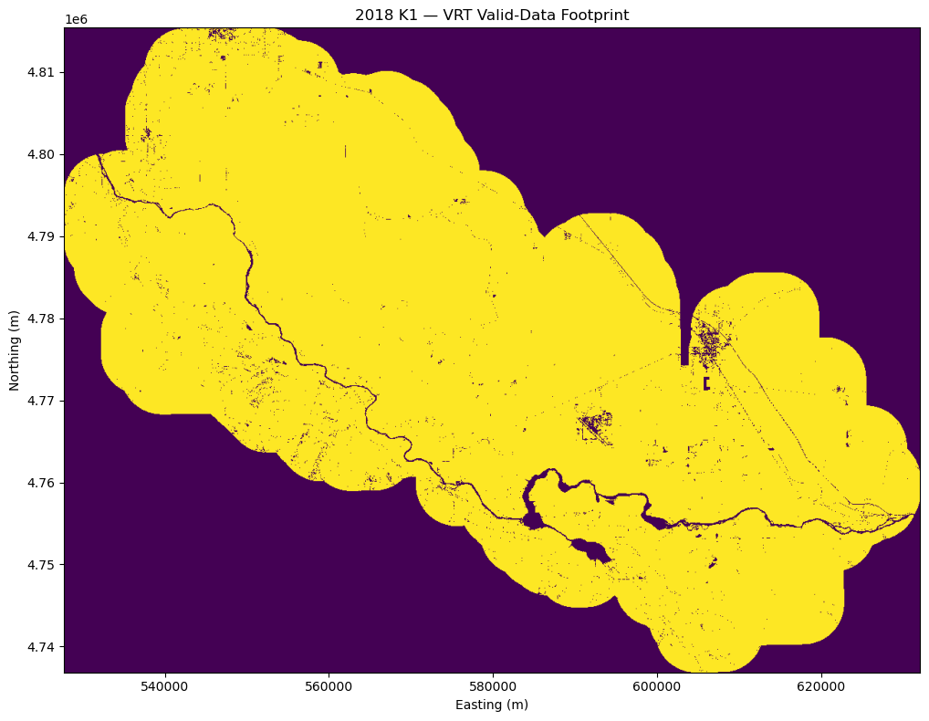

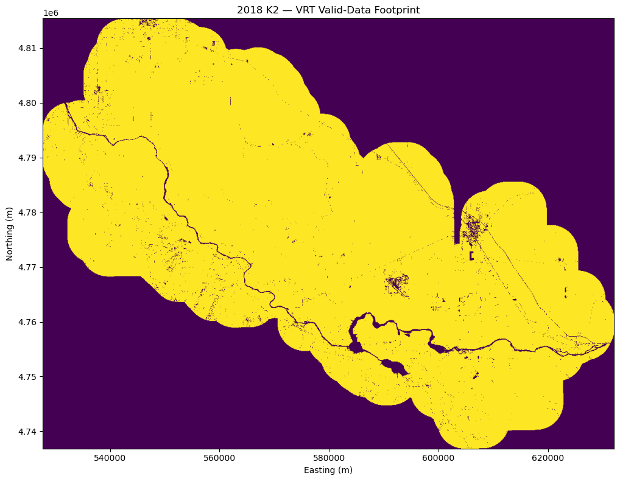

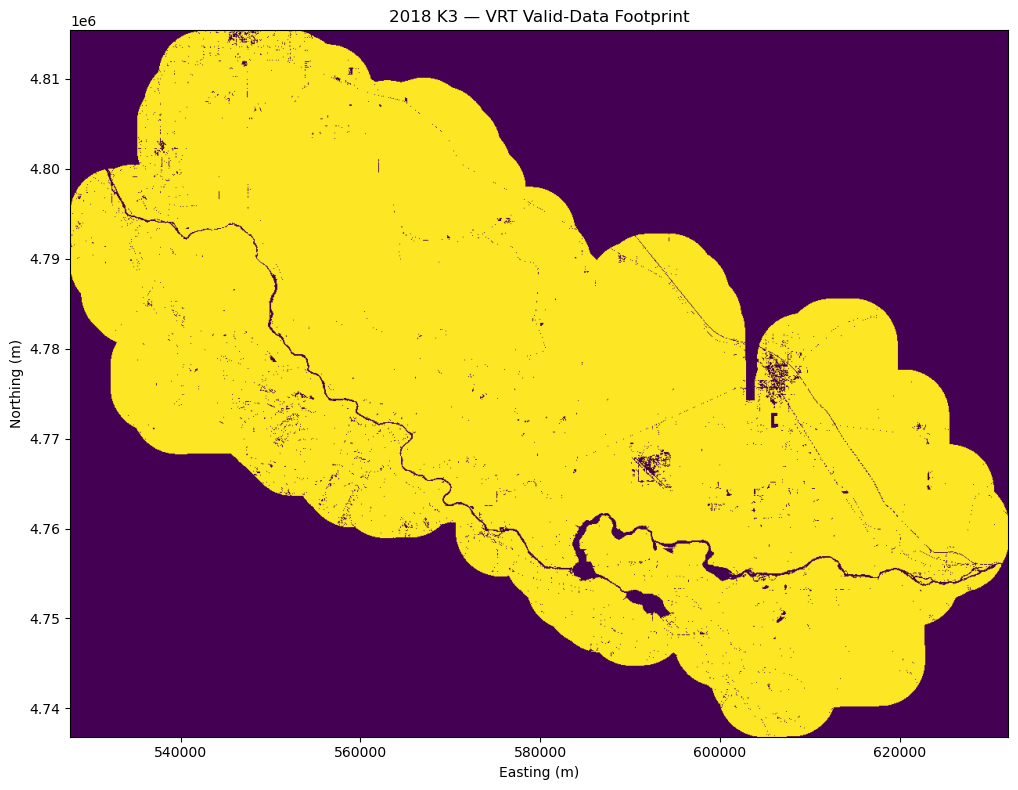

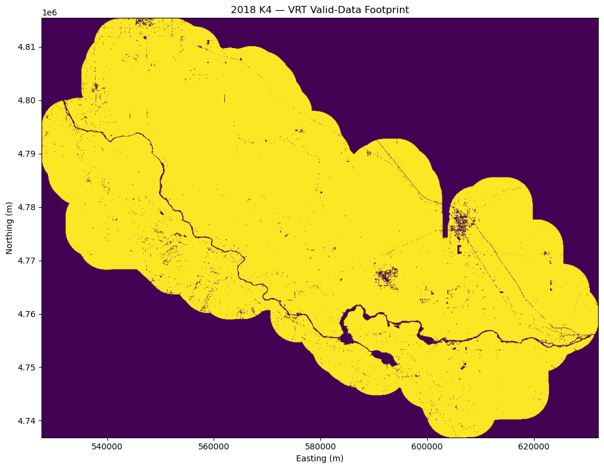

```python
import matplotlib.pyplot as plt
import rasterio
import numpy as np


# -------------------------------------------------------------------
# VISUALIZE VALID-DATA FOOTPRINT OF EACH VRT
# -------------------------------------------------------------------

for k in ["K1", "K2", "K3", "K4"]:

    vrt_path = VRT_DIR / f"2018_{k}.vrt"

    with rasterio.open(vrt_path) as src:

        display_width = 1200
        scale = display_width / src.width
        display_height = int(src.height * scale)

        data = src.read(
            1,
            out_shape=(display_height, display_width),
            masked=True,
            resampling=rasterio.enums.Resampling.nearest
        )

        valid = (~data.mask).astype(np.uint8)

        extent = [
            src.bounds.left,
            src.bounds.right,
            src.bounds.bottom,
            src.bounds.top,
        ]

    plt.figure(figsize=(12, 8))

    plt.imshow(
        valid,
        extent=extent,
        origin="upper",
        vmin=0,
        vmax=1
    )

    plt.title(f"2018 {k} — VRT Valid-Data Footprint")
    plt.xlabel("Easting (m)")
    plt.ylabel("Northing (m)")

    plt.tight_layout()
    plt.show()
```